**Dynamical Systems:**  
**Matrix Exponential**

Table of Contents

# 1. Matrix Exponential

The matrix exponential provides a powerful tool for solving systems of linear differential equations, generalizing the familiar scalar exponential function.

**Scalar Case: A Starting Point**

Consider the first-order linear scalar differential equation:

$$ \dot{u}(t) = a u(t). $$

Its solution is:

$$ u(t) = e^{at} u(0). $$

**Extension to Vector Case (Matrix)**

For a linear system of ODEs:

$$ \dot{\vec{u}}(t) = A \vec{u}(t), $$

the solution is:

$$ \vec{u}(t) = e^{A t} \vec{u}(0), $$

where $e^{A t}$ is the **matrix exponential**.

## 1.1. Matrix Exponential

**Matrix Exponential of a Diagonal Matrix (Intuition)**

If $A = \Lambda$ is diagonal:

$$ \Lambda = \begin{bmatrix} \lambda_1 & & \\ & \ddots & \\ & & \lambda_n \end{bmatrix}, $$

then:

$$ e^{\Lambda t} = \begin{bmatrix} e^{\lambda_1 t} & & 0 \\ & \ddots & \\ 0 & & e^{\lambda_n t} \end{bmatrix}. $$

**Diagonalization and Similarity**

If $A$ is diagonalizable, we have:

$$ A = S \Lambda S^{-1}, \quad \text{where } \Lambda \text{ is diagonal}, S \text{ contains eigenvectors}. $$

Thus:

$$ e^{A t} = S e^{\Lambda t} S^{-1}. $$

**The Exponential Function**

Recall the scalar exponential series:

$$ e^x = 1 + x + \frac{x^2}{2!} + \frac{x^3}{3!} + \cdots. $$

The derivative satisfies:

$$ \frac{d}{dx} e^x = e^x, $$

which is why $e^x$ solves $\dot{y} = y$.

**The Matrix Exponential Series**

Similarly, for matrices:

$$ e^A = I + A + \frac{A^2}{2!} + \frac{A^3}{3!} + \cdots, $$

and:

$$ e^{A t} = I + A t + \frac{A^2 t^2}{2!} + \frac{A^3 t^3}{3!} + \cdots. $$

Differentiating the matrix exponential with respect to $t$:

$$ \frac{d}{dt} e^{A t} = A e^{A t}. $$

**Similarity Transformation of Exponentials**

If $A = S \Lambda S^{-1}$, then:

$$ \begin{align*} e^{A} &= e^{S \Lambda S^{-1}} \\ &= I + S \Lambda S^{-1} + \frac{S \Lambda^2 S^{-1}}{2!} + \cdots \\ &= S \left( I + \Lambda + \frac{\Lambda^2}{2!} + \cdots \right) S^{-1} \\ &= S e^{\Lambda} S^{-1}. \end{align*} $$

Similarly:

$$ e^{A t} = S e^{\Lambda t} S^{-1}. $$

This framework connects solutions of linear systems, eigenvalues, and eigenvectors, and leads naturally to applications such as system stability analysis, modal decomposition, and control design.

## 1.2. Examples of Matrix Exponential

We now illustrate matrix exponentials with explicit examples.

**Example 1: Diagonal Matrix**

Let:

$$ A = \begin{bmatrix} 2 & 0 \\ 0 & -1 \end{bmatrix}. $$

Since $A$ is diagonal, its exponential is:

$$ e^{A t} = \begin{bmatrix} e^{2t} & 0 \\ 0 & e^{-t} \end{bmatrix}. $$

Thus, the solution of:

$$ \dot{\vec{u}} = A \vec{u}, \quad \vec{u}(0) = \begin{bmatrix} u_1(0) \\ u_2(0) \end{bmatrix}, $$

is:

$$ \vec{u}(t) = \begin{bmatrix} e^{2t} u_1(0) \\ e^{-t} u_2(0) \end{bmatrix}. $$

**Example 2: Non-Diagonalizable Matrix**

Let:

$$ A = \begin{bmatrix} 0 & 1 \\ 0 & 0 \end{bmatrix}. $$

Compute:

$$ A^2 = \begin{bmatrix} 0 & 0 \\ 0 & 0 \end{bmatrix}. $$

Thus:

$$ e^{A t} = I + A t = \begin{bmatrix} 1 & t \\ 0 & 1 \end{bmatrix}. $$

The system:

$$ \dot{\vec{u}} = A \vec{u}, \quad \vec{u}(0) = \begin{bmatrix} u_1(0) \\ u_2(0) \end{bmatrix}, $$

has solution:

$$ \vec{u}(t) = \begin{bmatrix} u_1(0) + t u_2(0) \\ u_2(0) \end{bmatrix}. $$

**Example 3: Diagonalizable Matrix**

Let:

$$ A = \begin{bmatrix} 3 & 1 \\ 0 & 2 \end{bmatrix}. $$

Find eigenvalues: $\lambda_1=3$, $\lambda_2=2$.

Eigenvectors:

$$ \vec{x}_1 = \begin{bmatrix} 1 \\ 0 \end{bmatrix}, \quad \vec{x}_2 = \begin{bmatrix} 1 \\ -1 \end{bmatrix}. $$

Thus:

$$ S = \begin{bmatrix} 1 & 1 \\ 0 & -1 \end{bmatrix}, \quad \Lambda = \begin{bmatrix} 3 & 0 \\ 0 & 2 \end{bmatrix}. $$

We can compute:

$$ S^{-1} = \begin{bmatrix} 1 & 1 \\ 0 & -1 \end{bmatrix}^{-1} = \begin{bmatrix} 1 & 1 \\ 0 & -1 \end{bmatrix}^{-1} = \frac{1}{-1} \begin{bmatrix} -1 & -1 \\ 0 & 1 \end{bmatrix}. $$

Then:

$$ e^{A t} = S e^{\Lambda t} S^{-1} = \begin{bmatrix} 1 & 1 \\ 0 & -1 \end{bmatrix} \begin{bmatrix} e^{3t} & 0 \\ 0 & e^{2t} \end{bmatrix} S^{-1}. $$

# 2. MATLAB Implementation

Consider the state-space system:

$$ \begin{align*} \left[ {\begin{matrix} \dot{x}_1 \\ \dot{x}_2 \\ \end{matrix} } \right] &= \left[ {\begin{matrix} 0 & 1 \\ -\omega_n^2 & -2\zeta \omega_n \\ \end{matrix} } \right] \left[ {\begin{array}{cc} x_1 \\ x_2 \\ \end{array} } \right] \\ \\y & = \left[ {\begin{matrix} 1 & 0 \end{matrix} } \right] \left[ {\begin{array}{cc} x_1 \\ x_2 \\ \end{array} } \right] \end{align*} $$

With parameters: $\omega_n = 2$, and $\zeta = 0.1$

**MATLAB Code**

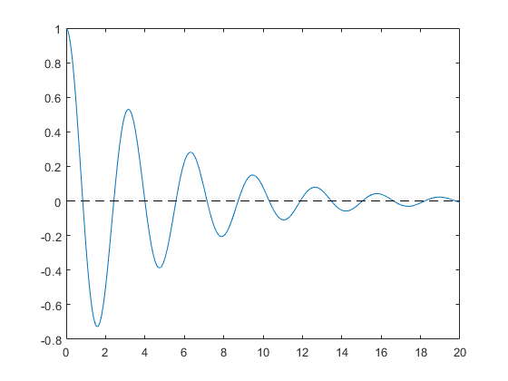

```matlab
% method 1: use expm (matrix exponential)

wn = 2; zeta = 0.1;
A = [0 1;-wn^2 -2*zeta*wn];

x0 = [1; 0];
t = linspace(0,20,200);
x = [];

for i = 1:length(t)
    x = [x, expm(A*t(i))*x0];
end

plot(t,x(1,:),t,zeros(size(t)),'--k')
```

Other Lectures

```matlab
from IPython.display import YouTubeVideo
YouTubeVideo('IZqwi0wJovM?start=1755', width = "560", height = "315")
```

[video not shown]

```matlab
from IPython.display import YouTubeVideo
YouTubeVideo('qbyeQum8qTE', width = "560", height = "315")
```

[video not shown]

```matlab
from IPython.display import YouTubeVideo
YouTubeVideo('dZfdKXxhnTM', width = "560", height = "315")
```

[video not shown]

```matlab
%%javascript
$.getScript('https://kmahelona.github.io/ipython_notebook_goodies/ipython_notebook_toc.js')
```